# Time Series Models

Mike Aguilar

### ACF

```r
rm(list=ls()) # clear workspace
cat("\014")  # clear console
```

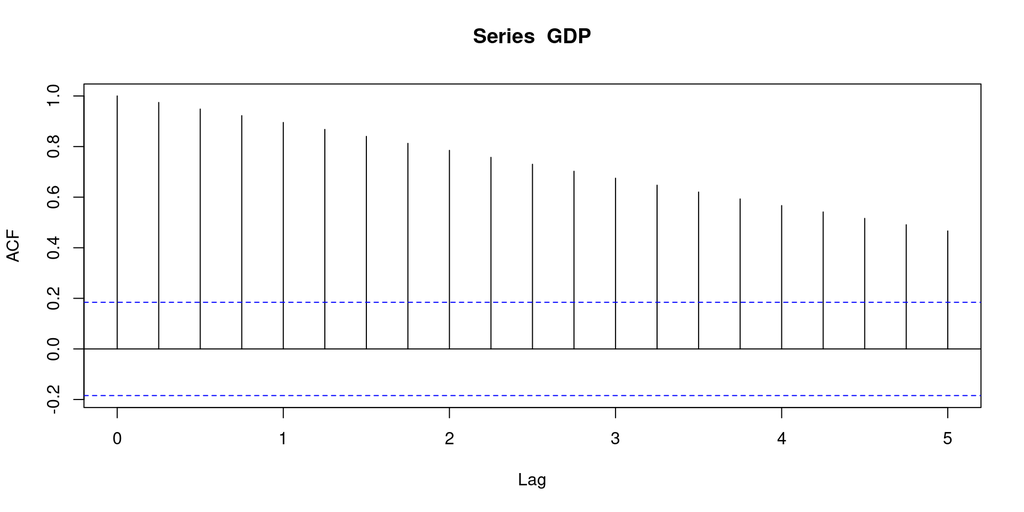

```r
library(Quandl)
Quandl_key = read.csv("quandlkey.csv",stringsAsFactors=FALSE)$Key
Quandl.api_key(Quandl_key)
startd<-"1990-01-01" #We want from Jan1990 forward.
endd<-"2018-01-01"
freq<-"quarterly"
GDP = Quandl("FRED/GDPC1", type="xts",start_date=startd, end_date=endd)
acf(GDP)
```

### PACF

```r
rm(list=ls()) # clear workspace
cat("\014")  # clear console
```

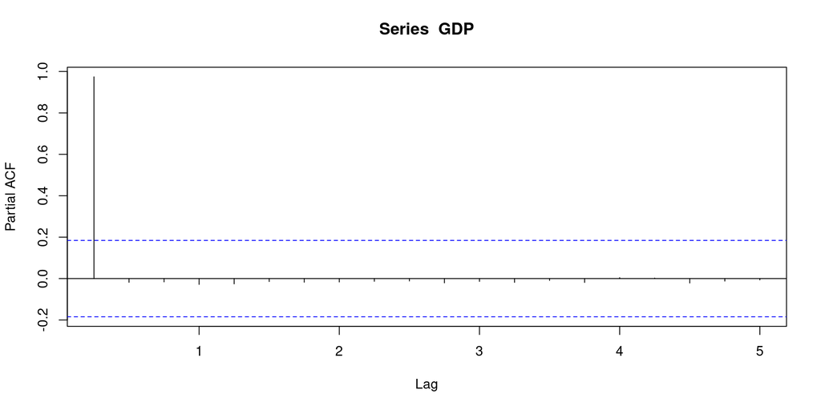

```r
library(Quandl)
Quandl_key = read.csv("quandlkey.csv",stringsAsFactors=FALSE)$Key
Quandl.api_key(Quandl_key)
startd<-"1990-01-01" #We want from Jan1990 forward.
endd<-"2018-01-01"
freq<-"quarterly"
GDP = Quandl("FRED/GDPC1", type="xts",start_date=startd, end_date=endd)
pacf(GDP)
```

### KPSS Test Stationarity

```r
rm(list=ls()) # clear workspace
cat("\014")  # clear console
```

```r
library(Quandl)
Quandl_key = read.csv("quandlkey.csv",stringsAsFactors=FALSE)$Key
Quandl.api_key(Quandl_key)
startd<-"1990-01-01"
endd<-"2018-01-01"
freq<-"quarterly"
GDP = Quandl("FRED/GDPC1", type="xts",start_date=startd, end_date=endd)


library(tseries)
# KPSS test for trend stationary
kpss.test(GDP, null="Trend")
```

```
##
##  KPSS Test for Trend Stationarity
##
## data:  GDP
## KPSS Trend = 0.37964, Truncation lag parameter = 4, p-value = 0.01
```

```r
# H0: trend stationarity
# Interpret: Low p-value -->reject the null hypothesis of trend stationary
```

### ADF Test Unit Root

```r
rm(list=ls()) # clear workspace
cat("\014")  # clear console
```

```r
library(Quandl)
Quandl_key = read.csv("quandlkey.csv",stringsAsFactors=FALSE)$Key
Quandl.api_key(Quandl_key)
startd<-"1990-01-01"
endd<-"2018-01-01"
freq<-"quarterly"
GDP = Quandl("FRED/GDPC1", type="xts",start_date=startd, end_date=endd)

# ADF Test for unit root, which is a common type of non-stationary
library(tseries)
adf.test(GDP, alternative = "stationary")
```

```
##
##  Augmented Dickey-Fuller Test
##
## data:  GDP
## Dickey-Fuller = -1.9904, Lag order = 4, p-value = 0.5806
## alternative hypothesis: stationary
```

```r
# H0: Not stationary
# Interpret: High p-value -->fail to reject the null hypothesis of non-stationary
```

### Fix NonStationary w/Diff.

```r
rm(list=ls()) # clear workspace
cat("\014")  # clear console
```

```r
library(Quandl)
Quandl_key = read.csv("quandlkey.csv",stringsAsFactors=FALSE)$Key
Quandl.api_key(Quandl_key)
startd<-"1990-01-01"
endd<-"2018-01-01"
freq<-"quarterly"
GDP = Quandl("FRED/GDPC1", type="xts",start_date=startd, end_date=endd)
colnames(GDP)[1]="Level" # Add column name

# Use ADF test to check if it is non-stationary
library(tseries)
adf.test(GDP$Level)
```

```
##
##  Augmented Dickey-Fuller Test
##
## data:  GDP$Level
## Dickey-Fuller = -1.9904, Lag order = 4, p-value = 0.5806
## alternative hypothesis: stationary
```

```r
# Interpret: High p-value -->fail to reject the null hypothesis of non-stationary. This series is non-stationary
```

In order to get this in a commonly used format, we will first take logs, noting that the a first diff of logs is a % change.

```r
GDP$LogLevel<- log(GDP$Level)
GDP$FirstDifLog<- diff(GDP$LogLevel, differences = 1)
GDP<-na.omit(GDP) # get rid of the NAs

# Now use the ADF test again to check if it is still non-stationary
adf.test(GDP$FirstDifLog)
```

```
##
##  Augmented Dickey-Fuller Test
##
## data:  GDP$FirstDifLog
## Dickey-Fuller = -4.2675, Lag order = 4, p-value = 0.01
## alternative hypothesis: stationary
```

```r
# Interpret: Low p-value --> reject the null hypothesis of non-stationarity
# Our data apears to now be stationary due to differencing
```

### Cointegration

```r
rm(list=ls()) # clear workspace
cat("\014")  # clear console
```

```r
library(quantmod)

startd <-"2013-01-01"
endd <-"2013-12-31"
SPY <- Ad(getSymbols("SPY", from = startd, to = endd, auto.assign = FALSE)) # get the adjusted closed
IVV <- Ad(getSymbols("IVV", from = startd, to = endd, auto.assign = FALSE)) # get the adjusted closed


### Step 1: Finding the integration order of each series
library(tseries)
kpss.test(SPY, null="Trend") # Low p-value --> reject H0 -->Non stationary.
```

```
##
##  KPSS Test for Trend Stationarity
##
## data:  SPY
## KPSS Trend = 0.20051, Truncation lag parameter = 5, p-value = 0.01581
```

```r
kpss.test(IVV, null="Trend") # Low p-value --> reject H0 -->Non stationary.
```

```
##
##  KPSS Test for Trend Stationarity
##
## data:  IVV
## KPSS Trend = 0.19944, Truncation lag parameter = 5, p-value = 0.01621
```

```r
# Take first difference
SPY_d1<-diff(SPY,differences = 1)
IVV_d1<-diff(IVV,differences = 1)
# ADF test for unit root
adf.test(na.omit(SPY_d1)) # low p-value --> reject H0 -->SPY_d1 is stationary --> SPY is I(1).
```

```
##
##  Augmented Dickey-Fuller Test
##
## data:  na.omit(SPY_d1)
## Dickey-Fuller = -5.742, Lag order = 6, p-value = 0.01
## alternative hypothesis: stationary
```

```r
adf.test(na.omit(IVV_d1)) # low p-value --> reject H0 -->IVV_d1 is stationary --> IVV is I(1).
```

```
##
##  Augmented Dickey-Fuller Test
##
## data:  na.omit(IVV_d1)
## Dickey-Fuller = -5.711, Lag order = 6, p-value = 0.01
## alternative hypothesis: stationary
```

```r
#Interpret: Series Y_t(IVV) and X_t(SPY) have the same integration order (1)


### Step 2: Estimate cointegration coefficient and get residuals
fit<-lm(IVV~SPY)
res<-fit$residuals

### Step 3: Do ADF test for unit root
adf.test(res) # Low p-value --> reject H0--> Residuals are stationary.
```

```
##
##  Augmented Dickey-Fuller Test
##
## data:  res
## Dickey-Fuller = -6.057, Lag order = 6, p-value = 0.01
## alternative hypothesis: stationary
```

```r
#Interpret: Y_t(IVV) and X_t(SPY) are co-integrated.
```

### ARIMA

```r
rm(list=ls()) # clear workspace
cat("\014")  # clear console
```

```r
library(Quandl)
Quandl_key = read.csv("quandlkey.csv",stringsAsFactors=FALSE)$Key
Quandl.api_key(Quandl_key)
startd<-"1990-01-01"
endd<-"2018-01-01"
freq<-"quarterly"
GDP <- Quandl("FRED/GDPC1", type="xts",start_date=startd, end_date=endd)
GDPGrowth <- diff(log(GDP)) # calculate log growth rate
GDPGrowth <- na.omit(GDPGrowth) # get rid of the NAs


# Specify the ARIMA model you with your choice or p, q values...(p=AR order, d=differencing, q= MA order)
AR1 <- arima(GDPGrowth, order = c(1, 0, 0)) # fit an AR(1) model
AR1 # print the model
```

```
##
## Call:
## arima(x = GDPGrowth, order = c(1, 0, 0))
##
## Coefficients:
##          ar1  intercept
##       0.4050      6e-03
## s.e.  0.0858      9e-04
##
## sigma^2 estimated as 2.917e-05:  log likelihood = 425.77,  aic = -845.54
```

```r
MA1 <- arima(GDPGrowth, order = c(0, 0, 1)) # fit an MA(1) model
MA1 # print the model
```

```
##
## Call:
## arima(x = GDPGrowth, order = c(0, 0, 1))
##
## Coefficients:
##          ma1  intercept
##       0.2868      6e-03
## s.e.  0.0733      7e-04
##
## sigma^2 estimated as 3.097e-05:  log likelihood = 422.46,  aic = -838.91
```

```r
AR1MA1 <- arima(GDPGrowth, order = c(1, 0, 1)) # fit an ARMA(1,1) model
AR1MA1 # print the model
```

```
##
## Call:
## arima(x = GDPGrowth, order = c(1, 0, 1))
##
## Coefficients:
##          ar1      ma1  intercept
##       0.7001  -0.3553     0.0060
## s.e.  0.1368   0.1750     0.0011
##
## sigma^2 estimated as 2.828e-05:  log likelihood = 427.46,  aic = -846.92
```

### ARIMA-Auto Lag Select

We can use the `auto.arima()` function from the `forecast` package to ask R to return the best ARIMA model according to either AIC, AICc or BIC value.

```r
rm(list=ls()) # clear workspace
cat("\014")  # clear console
```

```r
library(Quandl)
Quandl_key = read.csv("quandlkey.csv",stringsAsFactors=FALSE)$Key
Quandl.api_key(Quandl_key)
startd<-"1990-01-01"
endd<-"2018-01-01"
freq<-"quarterly"
GDP <- Quandl("FRED/GDPC1", type="xts",start_date=startd, end_date=endd)
GDPGrowth <- diff(log(GDP)) # calculate log growth rate
GDPGrowth <- na.omit(GDPGrowth) # get rid of the NAs

library(forecast)
AR <- auto.arima(GDPGrowth, max.q = 0) # set the maximum value of MA order q=0 to auto fit an AR model
AR # print the model
```

```
## Series: GDPGrowth
## ARIMA(2,0,0) with non-zero mean
##
## Coefficients:
##          ar1     ar2   mean
##       0.3292  0.1861  0.006
## s.e.  0.0921  0.0924  0.001
##
## sigma^2 = 2.89e-05:  log likelihood = 427.76
## AIC=-847.52   AICc=-847.15   BIC=-836.65
```

```r
MA <- auto.arima(GDPGrowth, max.p = 0) # set the maximum value of AR order p=0 to auto fit an AR model
MA # print the model
```

```
## Series: GDPGrowth
## ARIMA(0,0,3) with non-zero mean
##
## Coefficients:
##          ma1     ma2     ma3    mean
##       0.3227  0.2925  0.1340  0.0061
## s.e.  0.0921  0.0957  0.0816  0.0009
##
## sigma^2 = 2.937e-05:  log likelihood = 427.39
## AIC=-844.78   AICc=-844.21   BIC=-831.18
```

```r
ARMA <- auto.arima(GDPGrowth) # fit an ARMA model(the fitted model might be AR, MA or ARIMA)
ARMA # print the model
```

```
## Series: GDPGrowth
## ARIMA(2,0,0) with non-zero mean
##
## Coefficients:
##          ar1     ar2   mean
##       0.3292  0.1861  0.006
## s.e.  0.0921  0.0924  0.001
##
## sigma^2 = 2.89e-05:  log likelihood = 427.76
## AIC=-847.52   AICc=-847.15   BIC=-836.65
```

### SARIMA

A seasonal autoregressive integrated moving average (SARIMA) model is one step different from an ARIMA model based on the concept of seasonal trends.

#### Fit SARIMA Giving Model Orders

```r
rm(list=ls()) # clear workspace
cat("\014")  # clear console
```

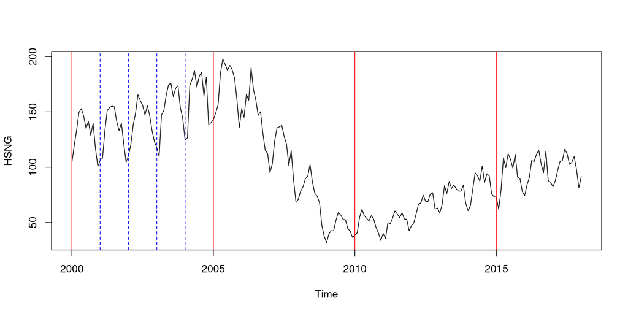

```r
library(Quandl)
Quandl_key = read.csv("quandlkey.csv",stringsAsFactors=FALSE)$Key
Quandl.api_key(Quandl_key)
startd<-"2000-01-01"
endd<-"2018-01-01"
ticker <- "FRED/HOUSTNSA" #New Privately-Owned Housing Units Started: Total Units
HSNG <- Quandl(ticker, type="ts",start_date=startd, end_date=endd)
{plot(HSNG)
abline(v = ts(c(2000,2005,2010,2015)),col = "red") # v is for vertical lines
abline(v = ts(c(2001,2002,2003,2004)), col = "blue", lty = 2)}
```

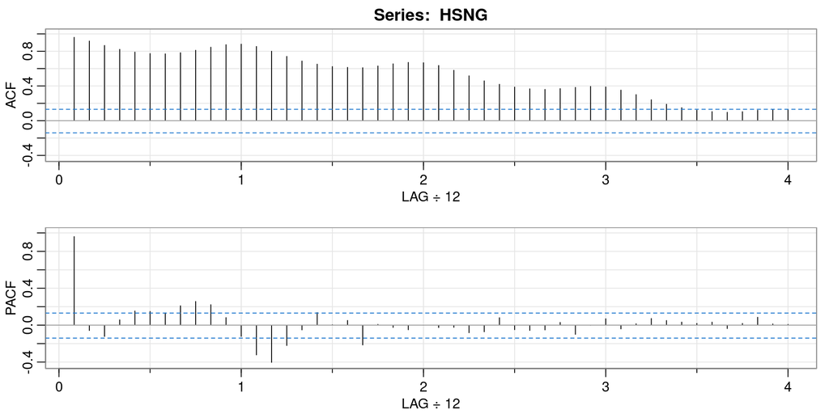

```
##      [,1]  [,2]  [,3] [,4] [,5] [,6] [,7] [,8] [,9] [,10] [,11] [,12] [,13]
## ACF  0.96  0.92  0.87 0.82 0.79 0.77 0.77 0.78 0.81  0.85  0.88  0.88  0.85
## PACF 0.96 -0.06 -0.12 0.06 0.15 0.15 0.13 0.21 0.26  0.22  0.08 -0.12 -0.32
##      [,14] [,15] [,16] [,17] [,18] [,19] [,20] [,21] [,22] [,23] [,24] [,25]
## ACF    0.8  0.74  0.69  0.65  0.62  0.61  0.61  0.63  0.65  0.67  0.67  0.64
## PACF  -0.4 -0.22 -0.05  0.14  0.00  0.05 -0.21  0.01 -0.02 -0.05  0.00 -0.03
##      [,26] [,27] [,28] [,29] [,30] [,31] [,32] [,33] [,34] [,35] [,36] [,37]
## ACF   0.58  0.52  0.46  0.42  0.39  0.37  0.36  0.37  0.38  0.39  0.39  0.35
## PACF -0.02 -0.08 -0.07  0.08 -0.05 -0.06 -0.05  0.03 -0.10  0.00  0.07 -0.04
##      [,38] [,39] [,40] [,41] [,42] [,43] [,44] [,45] [,46] [,47] [,48]
## ACF   0.30  0.24  0.19  0.15  0.12  0.10  0.10  0.10  0.12  0.13  0.12
## PACF  0.01  0.07  0.05  0.03  0.02  0.03 -0.04  0.02  0.09  0.01  0.01
```

```r
# Evidence of seasonality

### Decide the order of SARIMA
library(astsa)
acf2(HSNG, 48) # Interpret: The slow decay shown in the ACF is a sign that differencing may be required
```

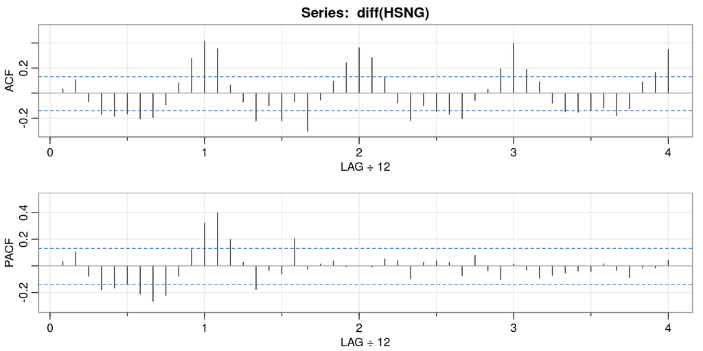

```
##      [,1] [,2]  [,3]  [,4]  [,5]  [,6]  [,7]  [,8]  [,9] [,10] [,11] [,12]
## ACF  0.03 0.11 -0.07 -0.17 -0.18 -0.17 -0.21 -0.19 -0.09  0.08  0.28  0.41
## PACF 0.03 0.11 -0.08 -0.18 -0.17 -0.14 -0.21 -0.27 -0.22 -0.08  0.12  0.32
##      [,13] [,14] [,15] [,16] [,17] [,18] [,19] [,20] [,21] [,22] [,23] [,24]
## ACF   0.35  0.06 -0.07 -0.22 -0.10 -0.22 -0.07 -0.31 -0.06  0.10  0.24  0.36
## PACF  0.40  0.20  0.03 -0.18 -0.03 -0.06  0.20 -0.02  0.01  0.04 -0.01  0.00
##      [,25] [,26] [,27] [,28] [,29] [,30] [,31] [,32] [,33] [,34] [,35] [,36]
## ACF   0.28  0.12 -0.08 -0.22 -0.10 -0.14 -0.17 -0.20 -0.06  0.03   0.2  0.40
## PACF -0.01  0.05  0.04 -0.10  0.03  0.04  0.03 -0.07  0.08 -0.04  -0.1  0.01
##      [,37] [,38] [,39] [,40] [,41] [,42] [,43] [,44] [,45] [,46] [,47] [,48]
## ACF   0.19  0.09 -0.08 -0.15 -0.15 -0.13 -0.12 -0.18 -0.12  0.09  0.17  0.35
## PACF -0.03 -0.09 -0.07 -0.05 -0.04 -0.04  0.02 -0.03 -0.09 -0.01 -0.02  0.04
```

```r
acf2(diff(HSNG), 48) # Interpret: Even with the first order of differencing, we observe that there is still slow decay in the ACF plots at a seasonal lag period of 12. This thus suggest a seasonal difference to be applied.
```